# Missing Data in Humanitarian Security Incidents

Analysis of information gaps across eight conflict-affected countries

Overview

Gender Analysis

Missing Fields

Heatmap

## Overall Data Completeness by Country

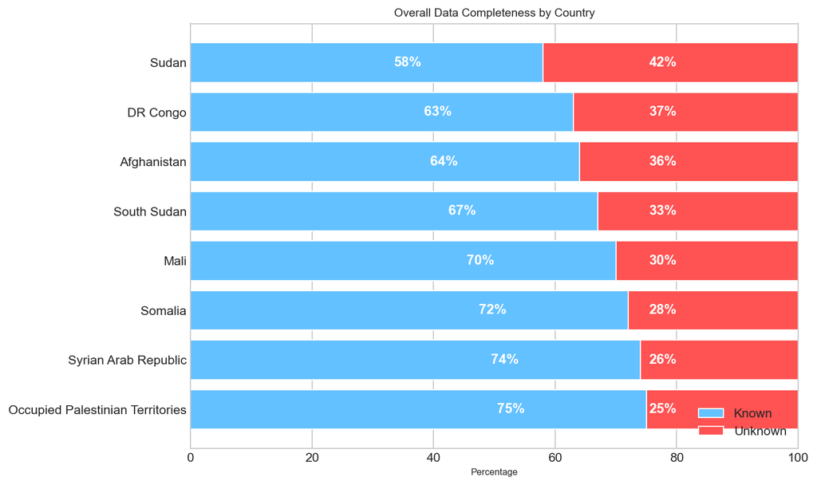

Between 25% and 45% of critical incident details are missing across the countries analyzed, with Sudan showing the highest rate of unknown values (over 40%). This chart reveals significant variation in data completeness across countries.

## Gender Data Completeness by Country

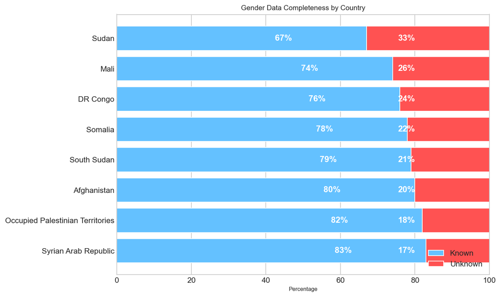

The chart reveals critical gaps in gender data collection across conflict-affected countries, with Sudan exhibiting the highest level of missing information. Syria leads in data completeness, yet nearly one-fifth of gender records remain undocumented.

## Missing Information by Field Type

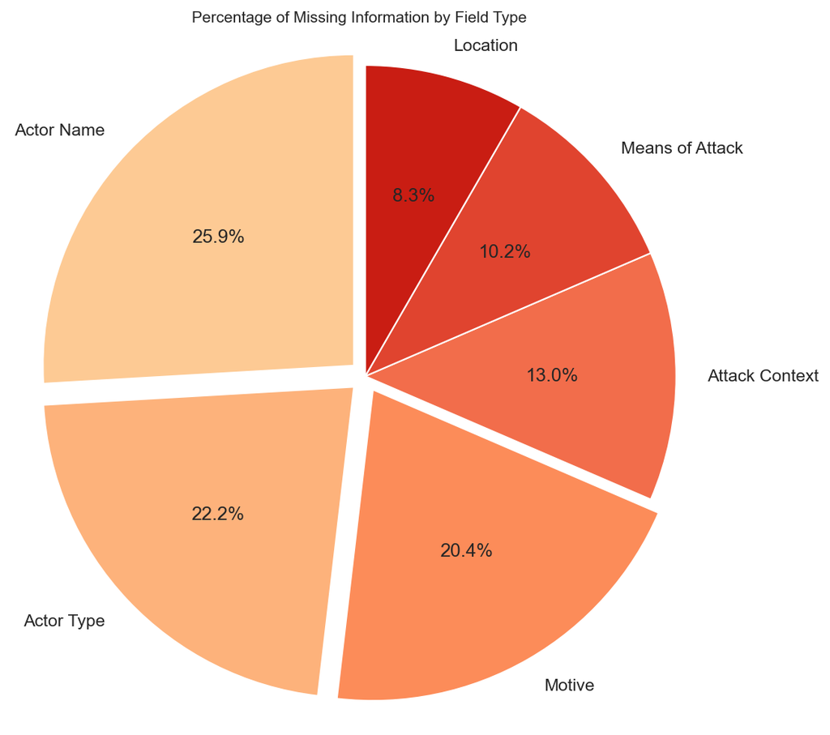

Perpetrator information (actor identity and type) and attack motives are consistently the most incomplete fields across all countries, creating a systematic accountability gap. Location data is relatively more complete, suggesting focused reporting priorities.

## Percentage of 'Unknown' Values by Country and Field

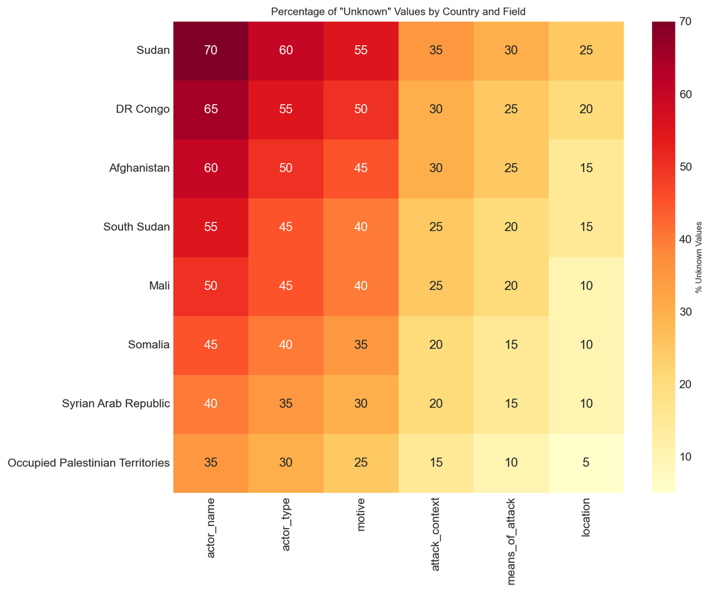

This heatmap reveals that missing data is not evenly distributed across columns or countries. Fields related to those responsible for incidents—specifically actor type, actor name, and motive—consistently show the highest rates of unknown values. Sudan shows particularly high missingness across all fields.

### Key Findings

- Substantial data gaps: Between 25% and 45% of critical incident details are missing across the countries analyzed.
- Country-specific reporting challenges: Sudan, DR Congo, and Afghanistan demonstrate the highest proportions of missing data.
- Systematic information biases: Perpetrator information and attack motives are consistently the most incomplete fields.
- Uneven documentation quality: Location data is generally more complete than other fields.
- Data reliability variation: The reliability of security analysis varies significantly by country.